# Analisis exploratorio de dataSet ‘Toyota Corolla’

# Modelo de Regresión Lineal post selección de atributos 1°

```r
linearMod_1 <- lm(formula = Price ~ ., data=clean_data)
summary(linearMod_1)
```

```
Call:
lm(formula = Price ~ ., data = clean_data)

Residuals:
    Min      1Q  Median      3Q     Max
-3186.0  -616.9   -37.8   614.0  3484.2

Coefficients:
              Estimate Std. Error t value Pr(>|t|)
(Intercept) -2.418e+03  2.107e+03  -1.148    0.252
Age_08_04   -1.039e+02  3.309e+00 -31.415  < 2e-16 ***
KM          -1.227e-02  1.608e-03  -7.630 7.25e-14 ***
Weight       1.837e+01  2.019e+00   9.096  < 2e-16 ***
---
Signif. codes:  0 ‘***’ 0.001 ‘**’ 0.01 ‘*’ 0.05 ‘.’ 0.1 ‘ ’ 1

Residual standard error: 972.2 on 740 degrees of freedom
Multiple R-squared:  0.6821,    Adjusted R-squared:  0.6808
F-statistic: 529.3 on 3 and 740 DF,  p-value: < 2.2e-16
```

## Plot Residuos

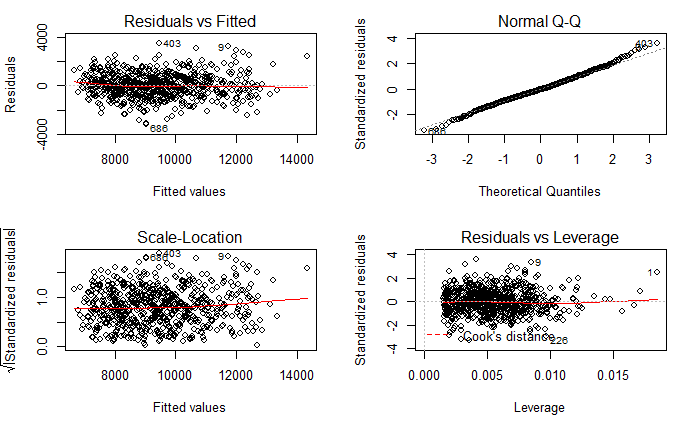

```r
par(mfrow=c(2,2))
plot(linearMod_1)
```

A partir de este modelo de regresión lineal, observo lo siguiente:

- En el grafico **Residuals vs Fitted** muestra un conjunto de puntos distribuidos alrrededor de una linea horizontal ubicada cercana a cero, no se observan valores que deformen la linea. Aparentemente no hay relacionanes no lineales que afecten el modelo.
- En el grafico **Normal Q-Q** muestra que los residuos no cumplen totalmente con una distribucion normal.
- En el grafico **Scale-Location** muestra un conjunto de puntos distribuidos alrrededor de una linea horizontal , lo cual representa una varianza similar entre los puntos, no se observan valores que deformen la linea, a excepcion de los valores 403, 9 y 686.
- En el grafico **Residuals vs Leverage** se observa que no existen valores que influyen el modelo de forma determinante.

## Plot Residuos: Histograma

```r
residuos = resid(linearMod_1)
hist(residuos, col = "blue", freq = F)
lines(density(residuos), col = "red", lwd=2)
```

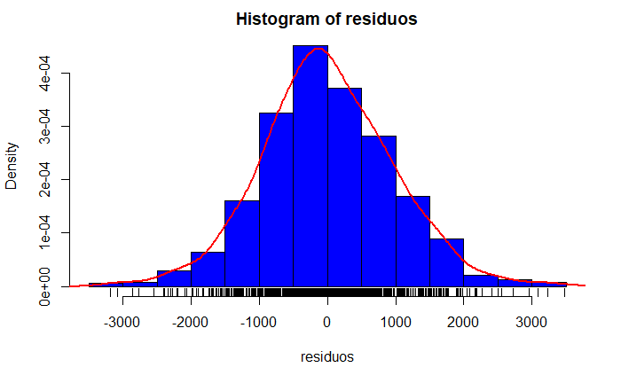

```r
rug(residuos)
```

# Prediccion

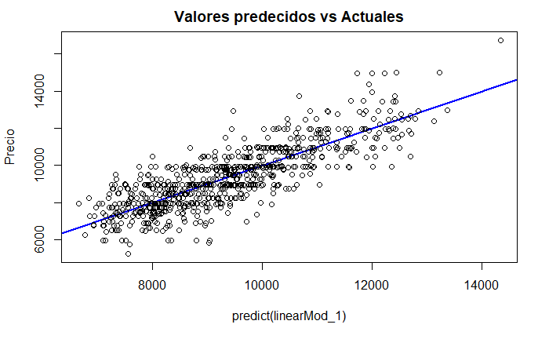

```r
predicciones <- predict(object = linearMod_1, newdata = clean_data)
plot(predict(linearMod_1), clean_data$Price, ylab="Precio", main = "Valores predecidos vs Actuales",
     abline(a=0, b=1, col="blue", lwd=2))
```

```r
NA
```

[figure not shown]

```r
par(mfrow=c(1,2))
hist(predicciones)
hist(clean_data$Price)
```

```r
rmse <- function(error)
{
    sqrt(mean(error^2))
}

mae <- function(error)
{
    mean(abs(error))
}
```

## RMSE y MAE

```r
e <- clean_data$Price - predicciones
rmse(e)
```

```
[1] 969.5541
```

```r
mae(e)
```

```
[1] 753.7611
```